# Predicting the Likelihood of Survival on the Titanic Spring 2024 Data Science Project

Contributors: Zain Zarger

## Member Contributions

Only Member: Zain Zarger, Contribution 100%

We, all team members, agree together that the above information is true, and we are confident about our contributions to this submitted project/final tutorial.

## Contribution Summary

I, Zain Zarger, did this entire tutorial on my own.

## Introduction

In this tutorial, I will walk you through the entire data science pipeline. To do this, I'll be making use of the tragedy of the Titanic, showing you how different factors had different effects on the survivability of individuals who were aboard the Titanic. I'll use data science to uncover the hidden patterns between who lived and who died on the night the Titanic sunk.

Why is that important? Understanding the patterns behind survival on the Titanic can help inform modern safety protocols in similar situations. By identifying the safety gaps that existed back then, we can uncover the systemic errors that led to such a large loss of life, and ensure that we never repeat them.

So, I now go forward with trying to answer the question: What factors affected survival the most on the Titanic?

## Data Curation

I chose the [Titanic - Machine Learning from Disaster](https://www.kaggle.com/c/titanic/overview) dataset from Kaggle. This dataset has a wide variety of information on each passenger, and seemed fitting for further analysis.

By downloading the dataset, I obtained the following three files:

- gender_submission.csv: Just a sample file showing how one is supposed to submit their responses to the Kaggle competition.
- test.csv: Data to test on for the Kaggle competition, which is currently not useful to us because it doesn't have the true labels attached to it.
- train.csv: Data to train our eventual model on.

To read the data, I just used the Pandas Python library. I also imported numpy and scipy to help with my analysis, and matplotlib and seaborn to help with my visualization. I also imported some helpful tools from the sklearn library.

```python
# Necessary Imports
import pandas as pd
import numpy as np
import scipy
from scipy.stats import chi2_contingency
import matplotlib.pyplot as plt
import seaborn as sns
from sklearn.metrics import accuracy_score, classification_report, confusion_matrix
from sklearn.linear_model import LogisticRegression
from sklearn.neighbors import KNeighborsClassifier
from sklearn.linear_model import SGDClassifier

# Read in the training data
train_df = pd.read_csv('/content/titanic/train.csv')

# Display first few rows of training data
train_df.head()
```

|  | PassengerId | Survived | Pclass | Name | Sex | Age | SibSp | Parch | Ticket | Fare | Cabin | Embarked |
| --- | --- | --- | --- | --- | --- | --- | --- | --- | --- | --- | --- | --- |
| 0 | 1 | 0 | 3 | Braund, Mr. Owen Harris | male | 22.0 | 1 | 0 | A/5 21171 | 7.2500 | NaN | S |
| 1 | 2 | 1 | 1 | Cumings, Mrs. John Bradley (Florence Briggs Th... | female | 38.0 | 1 | 0 | PC 17599 | 71.2833 | C85 | C |
| 2 | 3 | 1 | 3 | Heikkinen, Miss. Laina | female | 26.0 | 0 | 0 | STON/O2. 3101282 | 7.9250 | NaN | S |
| 3 | 4 | 1 | 1 | Futrelle, Mrs. Jacques Heath (Lily May Peel) | female | 35.0 | 1 | 0 | 113803 | 53.1000 | C123 | S |
| 4 | 5 | 0 | 3 | Allen, Mr. William Henry | male | 35.0 | 0 | 0 | 373450 | 8.0500 | NaN | S |

The training data consists of the following features:

1. PassengerId: A unique identifying number corresponding to each passenger
2. Survived: Whether the passenger survived the tragedy (0 means no, 1 mean yes)
3. Pclass: The class of the passenger's ticket (1st, 2nd, or 3rd)
4. Name: Name of the passenger
5. Sex: Sex of the passenger (Male or Female)
6. Age: Age of the passenger in years
7. SibSp: The number of siblings and spouses of the passenger aboard the Titanic
8. Parch: The number of parents and children of the passenger aboard the Titanic
9. Ticket: Ticket number of the passenger
10. Fare: The passenger's fare
11. Cabin: The cabin number of the passenger
12. Embarked: The passenger's port of embarkation (Cherbourg, Queenstown, or Southampton)

Now, we'll drop features that won't be relevant to our analysis, like passengers' ticket and cabin numbers, names, and passenger id.

```python
train_df = train_df.drop(['Ticket', 'Cabin', 'PassengerId', 'Name'], axis=1)

train_df.head()
```

|  | Survived | Pclass | Sex | Age | SibSp | Parch | Fare | Embarked |
| --- | --- | --- | --- | --- | --- | --- | --- | --- |
| 0 | 0 | 3 | male | 22.0 | 1 | 0 | 7.2500 | S |
| 1 | 1 | 1 | female | 38.0 | 1 | 0 | 71.2833 | C |
| 2 | 1 | 3 | female | 26.0 | 0 | 0 | 7.9250 | S |
| 3 | 1 | 1 | female | 35.0 | 1 | 0 | 53.1000 | S |
| 4 | 0 | 3 | male | 35.0 | 0 | 0 | 8.0500 | S |

Now, we'll convert categorical features into a numerical ones. For sex, we'll represent male as 0 and female as 1. For port of embarkation, we'll represent Cherbourg as 0, Queenstown as 1, and Southampton as 2. We'll fill in missing Embarked values with the mode since there are so few missing that it won't have a significant effect on our analysis. While we're at it, let's also make a dataframe column combining the number of siblings, spouses, parents, and children that each passenger had on board and simply call it 'Relatives.'

```python
train_df['Sex'] = train_df['Sex'].map( {'male': 0, 'female': 1} ).astype(int)

print("Training NaN values:", train_df['Embarked'].isna().sum())

train_df['Embarked'] = train_df['Embarked'].fillna(value=train_df['Embarked'].mode()[0])
train_df['Embarked'] = train_df['Embarked'].map( {'C': 0, 'Q': 1, 'S': 2} ).astype(int)
train_df['Relatives'] = train_df['SibSp'] + train_df['Parch']

train_df.head(5)
```

```
Training NaN values: 2
```

|  | Survived | Pclass | Sex | Age | SibSp | Parch | Fare | Embarked | Relatives |
| --- | --- | --- | --- | --- | --- | --- | --- | --- | --- |
| 0 | 0 | 3 | 0 | 22.0 | 1 | 0 | 7.2500 | 2 | 1 |
| 1 | 1 | 1 | 1 | 38.0 | 1 | 0 | 71.2833 | 0 | 1 |
| 2 | 1 | 3 | 1 | 26.0 | 0 | 0 | 7.9250 | 2 | 0 |
| 3 | 1 | 1 | 1 | 35.0 | 1 | 0 | 53.1000 | 2 | 1 |
| 4 | 0 | 3 | 0 | 35.0 | 0 | 0 | 8.0500 | 2 | 0 |

Now, let's fill in the Age column by utilizing the median values across Sex and Pclass.

```python
guess_ages = np.zeros((2, 3))

for i in range(2):
  for j in range(1, 4):
    guess_df = (train_df[(train_df['Sex'] == i) & (train_df['Pclass'] == j)]['Age']).dropna()
    age_guess = guess_df.median()
    guess_ages[i,j-1] = round(age_guess * 2) / 2

def replace_age(row):
  if pd.isna(row['Age']):
    return guess_ages[int(row['Sex']), int(row['Pclass']-1)]
  else:
    return row['Age']

train_df['Age'] = train_df.apply(replace_age, axis=1)
```

## Exploratory Data Analysis

Let's start off with a simple correlation matrix and heatmap to see if we can observe any obvious trends in the data.

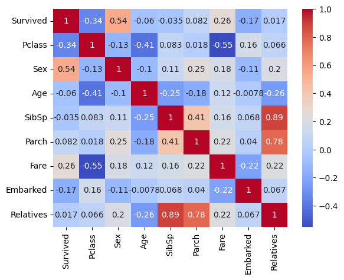

```python
correlation_matrix = train_df.corr()
sns.heatmap(correlation_matrix, annot=True, cmap='coolwarm')
plt.show()
```

From the heatmap, it doesn't seem that there are many glaring trends that influence survival. The category with the strongest correlation to survival seems to be Sex, which has a moderate correlation. This implies that females were more likely to survive the tragedy.

Next, we'll take a look at outlier detection in some key features, like age, relatives, and ticket fare.

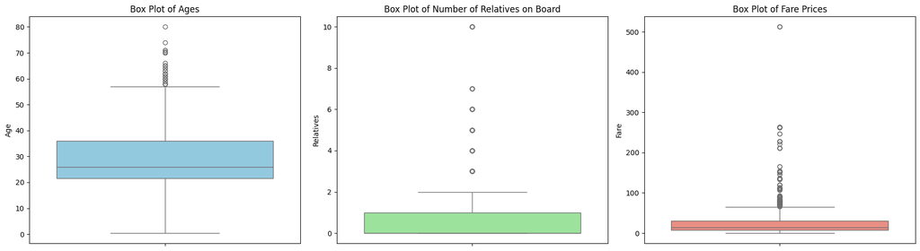

```python
fig, bx = plt.subplots(1, 3, figsize=(18, 5))

sns.boxplot(y=train_df['Age'], ax=bx[0], color='skyblue')
bx[0].set_title('Box Plot of Ages')

sns.boxplot(y=train_df['Relatives'], ax=bx[1], color='lightgreen')
bx[1].set_title('Box Plot of Number of Relatives on Board')

sns.boxplot(y=train_df['Fare'], ax=bx[2], color='salmon')
bx[2].set_title('Box Plot of Fare Prices')

plt.tight_layout()
```

It seems that there are several outliers in each of the categories we displayed using the box plots. It appears a few individuals were either far older, had more relatives on board, or paid much more for their fare than most aboard the Titanic did.

Finally, let's do a basic hypothesis test on the data.

H0: The class of a passenger's ticket DOES NOT have an effect on their likelihood of survival.

HA: The class of a passenger's ticket DOES have an effect on their likelihood of survival.

Assume alpha value of 0.05, and we'll apply a chi-square test because we want to see if there is a statistically significant relationship between the ticket class and the likelihood of the person surviving, which are two sets of categorical data.

```python
contingency_table = pd.crosstab(train_df['Pclass'], train_df['Survived'])
print("Contingency Table:\n", contingency_table)

print()

res = chi2_contingency(contingency_table)
print("Chi-Square Test P-value: ", res.pvalue)
```

```
Contingency Table:
 Survived    0    1
Pclass
1          80  136
2          97   87
3         372  119

Chi-Square Test P-value:  4.549251711298793e-23
```

Now, let's plot out the data.

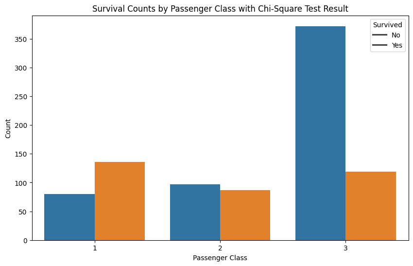

```python
plot_data = contingency_table.stack().reset_index()
plot_data.columns = ['Pclass', 'Survived', 'Count']

# Plotting
plt.figure(figsize=(10, 6))
sns.barplot(x='Pclass', y='Count', hue='Survived', data=plot_data)
plt.title('Survival Counts by Passenger Class with Chi-Square Test Result')
plt.xlabel('Passenger Class')
plt.ylabel('Count')
plt.legend(title='Survived', labels=['No', 'Yes'])

# Show the plot
plt.show()
```

Since we got a p-value far below the alpha value of 0.05, then we can REJECT the null hypothesis. Then indeed, we can conclude that the class of a passenger's ticket DOES have an effect on the likelihood that the passenger survives, which the plotted data also visually correlates.

## Primary Analysis

Now, I'll attempt to answer the question I posed in the introduction. To do this, I will use a CLASSIFICATION approach. Our primary target variable is whether a passenger survived, a binary outcome, which classification models are especially adept at handling.

First, let's get everything set up.

```python
X_train = train_df.drop("Survived", axis=1)
Y_train = train_df["Survived"]
```

One type of classifier we can try is a Logistic Regression, which, despite its name, is a classification technique.

```python
log = LogisticRegression(max_iter=200)
log.fit(X_train, Y_train)

Y_pred = log.predict(X_train)

print("CLASSIFICATION REPORT FOR LOGISTIC REGRESSION: \n", classification_report(Y_train, Y_pred))

coeff_df = pd.DataFrame(train_df.columns.delete(0))
coeff_df.columns = ['Feature']
coeff_df["Correlation"] = pd.Series(log.coef_[0])

coeff_df.sort_values(by='Correlation', ascending=False)
```

```
CLASSIFICATION REPORT FOR LOGISTIC REGRESSION:
               precision    recall  f1-score   support

           0       0.83      0.87      0.85       549
           1       0.78      0.70      0.74       342

    accuracy                           0.81       891
   macro avg       0.80      0.79      0.79       891
weighted avg       0.81      0.81      0.81       891
```

|  | Feature | Correlation |
| --- | --- | --- |
| 1 | Sex | 2.603440 |
| 4 | Parch | 0.059077 |
| 5 | Fare | 0.001941 |
| 2 | Age | -0.042743 |
| 7 | Relatives | -0.139346 |
| 6 | Embarked | -0.193242 |
| 3 | SibSp | -0.198423 |
| 0 | Pclass | -1.152330 |

From the logistic regression, we can glean the exact info that we were looking for. There appears to be a strong positive correlation between sex and survival, i.e. females were more likely to survive than males. Additionally, there is a strong negative correlation between pclass and survival, i.e. passengers with numerically lower (better) ticket classes were more likely to survive than those with numerically higher (worse) ticket classes. Indeed, if we repeat our process but only feed the logistic regression info about the sex and pclass of the passengers, it is still able to reach a similar level of accuracy, exhibiting just how important those two factors were in determining survival.

```python
X_sex_class = X_train[['Sex', 'Pclass']]

log = LogisticRegression(max_iter=200)
log.fit(X_sex_class, Y_train)

Y_pred = log.predict(X_sex_class)

print("CLASSIFICATION REPORT FOR LOGISTIC REGRESSION: \n", classification_report(Y_train, Y_pred))

coeff_df2 = pd.DataFrame(X_sex_class.columns)
coeff_df2.columns = ['Feature']
coeff_df2["Correlation"] = pd.Series(log.coef_[0])

coeff_df2.sort_values(by='Correlation', ascending=False)
```

```
CLASSIFICATION REPORT FOR LOGISTIC REGRESSION:
               precision    recall  f1-score   support

           0       0.81      0.85      0.83       549
           1       0.74      0.68      0.71       342

    accuracy                           0.79       891
   macro avg       0.78      0.77      0.77       891
weighted avg       0.78      0.79      0.78       891
```

|  | Feature | Correlation |
| --- | --- | --- |
| 0 | Sex | 2.553605 |
| 1 | Pclass | -0.936827 |

## Visualization

Let's take some time and plot out the correlation values of the original logistic regression in an easy to parse bar plot.

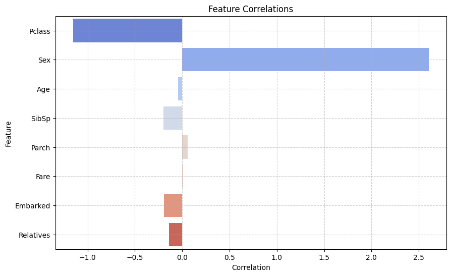

```python
import warnings
warnings.simplefilter(action='ignore', category=FutureWarning)

plt.figure(figsize=(10, 6))
sns.barplot(x='Correlation', y='Feature', data=coeff_df, palette='coolwarm')
plt.title('Feature Correlations')
plt.xlabel('Correlation')
plt.ylabel('Feature')
plt.grid(True, linestyle='--', alpha=0.6)
```

Wow! Look at those correlations!

## Conclusions

My analysis revealed two features that impacted survivability on the Titanic the most: Sex and Ticket Class. Both of these appear to make sense. We know that women were given priority for lifeboats, which likely contributes to the strong correlation we see. Additionally, passengers in higher classes (lower pclass values) were located closest to the lifeboats, and thus could evacuate much quicker and easier. This raises questions about how people from different socioeconomic backgrounds are treated differently in emergency situations, suggesting that a higher socioeconomic status possibly affords one a better chance of survival.

One of the most surprising of my findings was that age appeared to not have much correlation with survival at all; before going into this project, I was under the impression that children were also given priority on lifeboats.

Ultimately, my insights align well with actual historical accounts of the Titanic, which emphasized the role of sex and ticket class in the survival of the passengers. My logistic regression was able to provide a decent understanding of the factors that went into survival on the Titanic.

However, this analysis is ultimately just a starting point. It is possible that with further research, more detailed passenger data, and more sophisticated analytical techniques, one could uncover even deeper insights into the factors that influenced survival aboard the Titanic.